# Statistical Testing and Effect Size

Pietro Franceschi | pietro.franceschi@fmach.it

## The BIG question

⚠️ **The question:**  
Is what I’m observing **true beyond my sample**? Can I draw general conclusions from a limited set of samples?

In presence of variability, there will always be the possibility that what I observe in my data cannot be generalized at the population level.

- measure more samples
- validate
- give a measure of my **confidence** in the results

## Statistical testing

Due to variability, it is impossible to get **certain** answers from an experiment. The best one can do is to try to **quantify the level of confidence**.

Statistical testing is a procedure which allows us to quantify this level of confidence

## The concept

1. Suppose that what we observe is the result of chance alone (Null Hypothesis - H0)
2. Use statistics to calculate the probability of getting at least what we observe under H0 (by chance!) (*p-value*)
3. Set a threshold of reasonable confidence (0.05, 0.01, …)

## p-value worship

[figure not shown]

## Example: lowering cholesterol

- Suppose that the level of cholesterol in the population is normally distributed with mean 200 and standard deviation 50
- We claim that a new secret drug we recently invented **significantly** reduces the cholesterol level in the population
- To prove it we get a group of 50 people, we treat them with the drug and we measure their average cholesterol level. This mean turns out to be **193**.
- Is this pilot study supporting my claim? i.e. is the difference between 193 and 200 significant?

## Let’s test that!

1. Suppose that the drug has no effect (H0) … but then my 50 people are a random drawing from the population
2. Calculate the distribution of the mean level of cholesterol in groups of 50 people coming from the population … mind the gap! … this is not the distribution of cholesterol in the population!
3. Calculate the probability of obtaining less than **193** from this distribution (*p-value*)
4. Reject H0 if the p-value is lower than the selected threshold (typically 0.05)

## Let’s plot it!

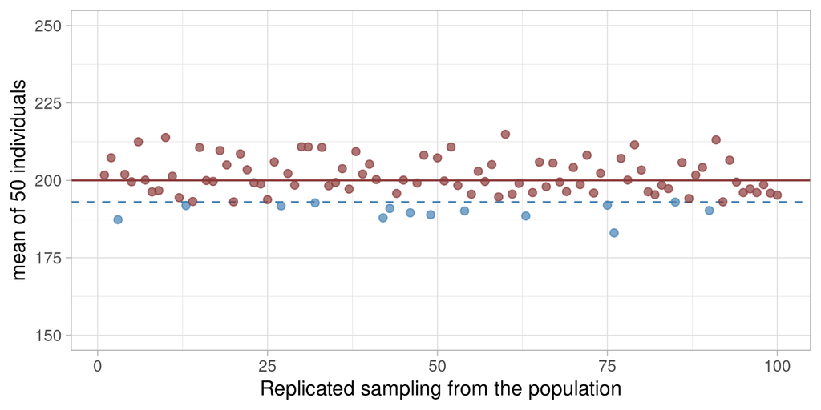

## What we see

- The means of the different groups are different
- The distribution of the means is nicely centered around the population mean!
- The dashed blue line is the mean of my 50 treated people (193!)
- The blue dots are “random” draws from the population with an average cholesterol lower than the one we observed: they get below 193 by chance
- Getting at least that value only by chance is not extremely unlikely … 14 blue dots out of 100 (p ≈ 0.14!)

I cannot reject H0 at the 0.05 level …

## More on this …

So you see … we need a **probability** and we also need a **threshold** (0.05)

The correct wording in my paper should be

*” … the results are not statistically significant at the 0.05 level”* …

⚠️ … but they are significant at the 0.15 level!

## More samples!

I’m stubborn, so I’m convinced that the drug is really working. We redo the same study with a test group of **500** people and we observe once more an average level of 193 …

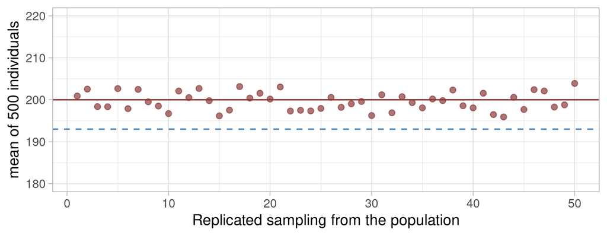

Magic! No more blue dots: now it is significant at the 0.05 level! It is extremely unlikely to get an average of 193 in a group of 500 people if the drug has no effect

## Take-home messages

⚠️ **We are never sure!**

- The choice of a threshold (here 0.05) for statistical significance is arbitrary
- With more samples we can “see” smaller differences
- Is statistical significance the only thing we are looking for?

## Back to our magic drug …

Unfortunately it turns out that our drug is not so good … apparently it reduces the cholesterol by only 1% (from 200 to 198)

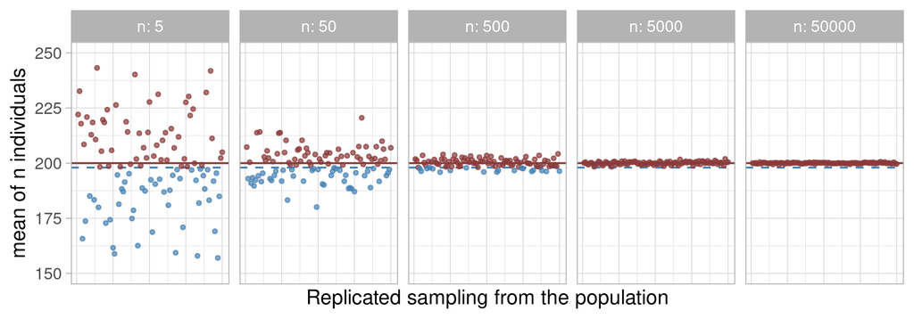

With 50000 people even a 1% reduction becomes “significant”

## Is a low *p-value* the only thing we need?

- Is a reduction of 1% really useful/relevant?
- A large number of samples will make tiny differences statistically significant!
- Statistical significance does not mean biological/agronomic/medical relevance

The *p-value* alone cannot be used to judge the relevance of a research result …

## Common misconceptions

- *p-values* deal with the probability of obtaining a result by chance, not with the strength of an effect
- strong effects with low variability **will** result in low *p*
- the reverse is not necessarily true!
- “look, I have a low *p-value*!” is not the only thing to look for

## Measuring the *effect size*

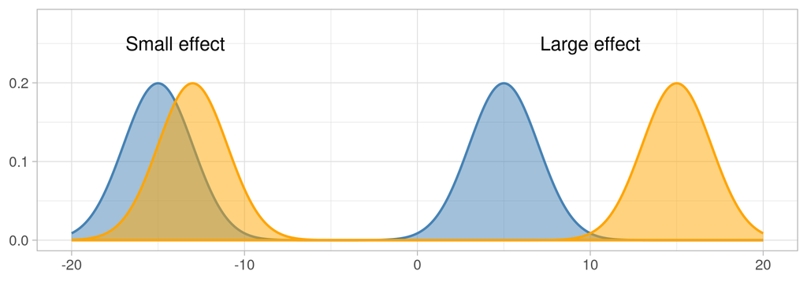

## Effect size: notes

1. The difference in means is not sufficient
2. The measure should take into account the variability
3. The variability of the population, not the one of the sampling distribution ;-)

⚠️ **Fold change:**  
plain or robust, it only says **where** the effect is, not how large it is compared to the variability

Scale the log fold change by the variability → **Cohen’s d on log-transformed data**  
(non-parametric alternative: probability of superiority)

## Cohen’s d

$$d = \frac{\bar{x}_{1} - \bar{x}_{2}}{s}$$

Where

- $\bar{x}$ are the estimates of the population means
- $s$ is the estimate of the population standard deviation (pooled)

## Let’s *see*

- 2 populations: $\mu_{1}=0$, $\mu_{2}=5$, $\sigma=5$ (so the true $d = 1$)
- *t-test* to test the difference
- 100 simulated studies for each sample size

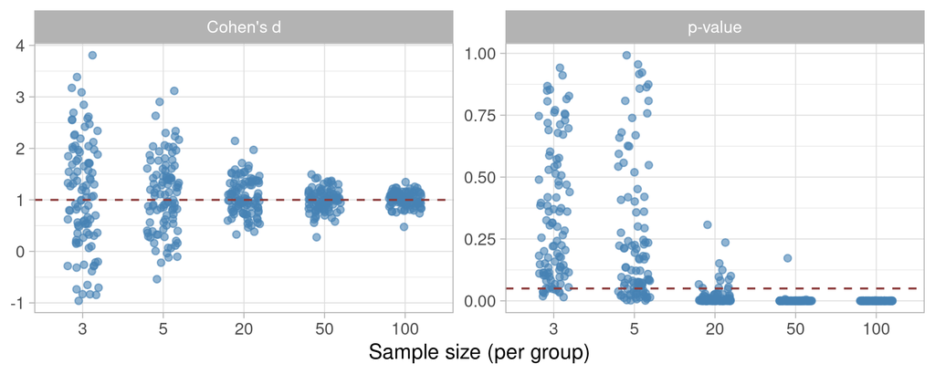

## Effect size and sample size

- With three samples the variability of both p and d is large
- … and so is the chance of calling the difference not significant

Even the effect size does not tell me if something is relevant!

## Effect size and significance: the volcano plot

Very popular in metabolomics papers:

- x-axis: log₂ fold change — the *size* of the effect (?)
- y-axis: $-\log_{10}(p)$ — the *confidence* in the effect

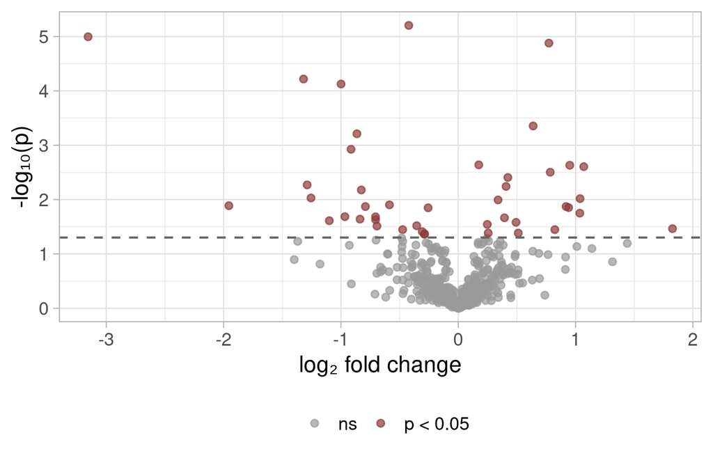

⚠️ The fold change ignores the variability: the same fold change can be a huge effect for a stable metabolite and pure noise for a variable one.

## Volcano plot with Cohen’s d

Same data, but on the x-axis a real effect size: Cohen’s d

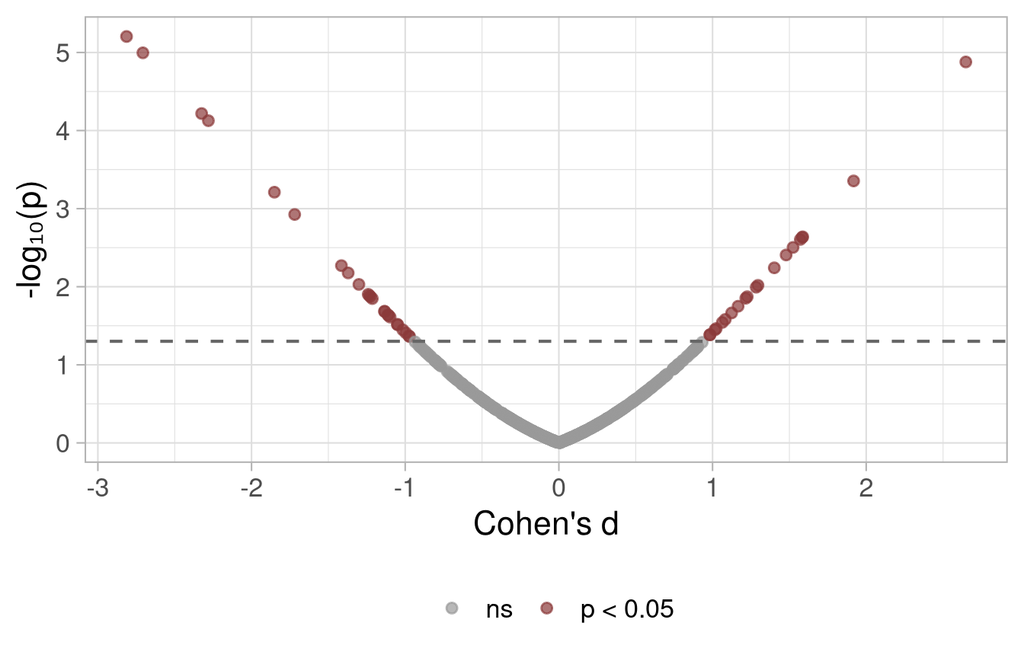

The “volcano” collapses on a curve: for a given sample size, $t = d \sqrt{n/2}$, so p-value and effect size carry the same information

## Report effect sizes with their uncertainty

Cohen’s d with its 95% confidence interval for the 20 metabolites with the smallest p-value

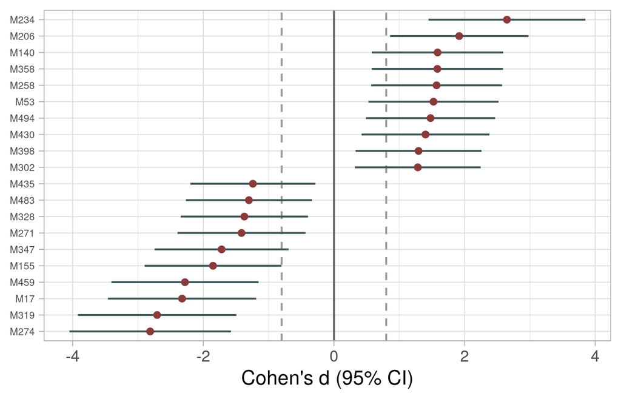

With few samples, even “significant” effects are estimated with large uncertainty

With 500 metabolites, many of the p < 0.05 are false positives: we need to correct the p-values → **multiple testing**